# Chapter 2: Probability for Statistical Computing

We will **briefly** review some definitions and concepts in probability and statistics that will be helpful for the remainder of the class.

Just like we reviewed computational tools (`R` and packages), we will now do the same for probability and statistics.

**Note:** This is not meant to be comprehensive. I am assuming you already know this and maybe have forgotten a few things.

[figure not shown]

https://xkcd.com/892/

Alternative text: “Hell, my eighth grade science class managed to conclusively reject it just based on a classroom experiment. It’s pretty sad to hear about million-dollar research teams who can’t even manage that.”

# 1 Random Variables and Probability

**Definition 1.1** A *random variable* is a function that maps sets of all possible outcomes of an experiment (sample space $\Omega$) to $\mathbb{R}$.

**Example 1.1**

**Example 1.2**

**Example 1.3**

Types of random variables –

**Discrete** take values in a countable set.

**Continuous** take values in an uncountable set (like $\mathbb{R}$)

## 1.1 Distribution and Density Functions

**Definition 1.2** The *probability mass function (pmf)* of a random variable $X$ is $f_X$ defined by
$$f_X(x) = P(X = x)$$
where $P(\cdot)$ denotes the probability of its argument.

There are a few requirements of a **valid** pmf

**Example 1.4** Let $\Omega =$ all possible values of a roll of a single die $= \{1, \dots, 6\}$ and $X$ be the outcome of a single roll of one die $\in \{1, \dots, 6\}$.

A pmf is defined for **discrete variables**, but what about **continuous**? Continuous variables do not have positive probability pass at any single point.

**Definition 1.3** The *probability density function (pdf)* of a random variable $X$ is $f_X$ defined by
$$P(X \in A) = \int\limits_{x \in A} f_X(x) dx.$$

$X$ is a continuous random variable if there exists this function $f_X \ge 0$ such that for all $x \in \mathbb{R}$, this probability exists.

For $f_X$ to be a valid pdf,

There are many named pdfs and cdfs that you have seen in other class, e.g.

**Example 1.5** Let
$$f(x) = \begin{cases}
c(4x - 2x^2) & 0 < x < 2 \\
0 & \text{otherwise}
\end{cases}$$

Find $c$ and then find $P(X > 1)$

**Definition 1.4** The *cumulative distribution function (cdf)* for a random variable $X$ is $F_X$ defined by
$$F_X(x) = P(X \le x), \quad x \in \mathbb{R}.$$

The cdf has the following properties

A random variable $X$ is *continuous* if $F_X$ is a continuous function and *discrete* if $F_X$ is a step function.

**Example 1.6** Find the cdf for the previous example.

Note $f(x) = F'(x) = \frac{dF(x)}{dx}$ in the continuous case.

Recall an indicator function is defined as

$$\mathbb{1}_{\{A\}} = \begin{cases} 1 & \text{if } A \text{ is true} \\ 0 & \text{otherwise} \end{cases}.$$

**Example 1.7**

**Example 1.8** If $X \sim N(0,1)$, the pdf is $f(x) = \frac{1}{\sqrt{2\pi}}\exp\left(-\frac{x^2}{2}\right)$ for $-\infty < x < \infty$.

If $f(x) = \frac{c}{\sqrt{2\pi}} \exp\left(-\frac{x^2}{2}\right)\mathbb{1}_{\{x > 0\}}$, what is $c$?

## 1.2 Two Continuous Random Variables

**Definition 1.5** The *joint pdf* of the continuous vector $(X,Y)$ is defined as
$$P((X, Y) \in A) = \iint\limits_{A} f_{X,Y}(x, y) dx dy$$
for any set $X \subset \mathbb{R}^2$.

Joint pdfs have the following properties

and a support defined to be $\{(x, y):f_{X,Y}(x,y) > 0\}$.

**Example 1.9**

The *marginal densities* of $X$ and $Y$ are given by

$$f_X(x) = \int\limits_\infty^\infty f_{X,Y}(x,y) dy \qquad\text{and}\qquad f_Y(y) = \int\limits_\infty^\infty f_{X,Y}(x,y) dx;$$

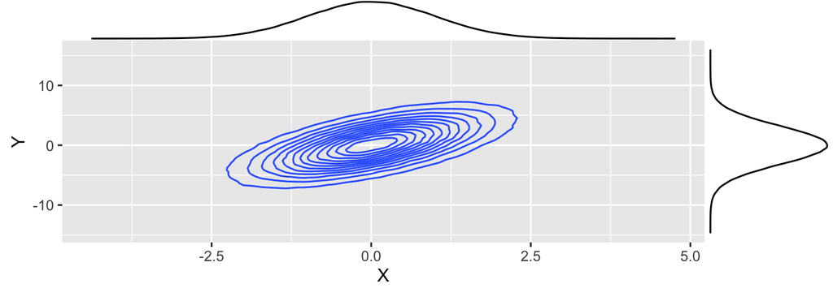

**Example 1.10** (From Devore (2008) Example 5.3, pg. 187) A bank operates both a drive-up facility and a walk-up window. On a randomly selected day, let $X$ be the proportion of time that the drive-up facility is in use and $Y$ is the proportion of time that the walk-up window is in use.

The the set of possible values for $(X, Y)$ is the square $D = \{(x, y): 0 \le x \le 1, 0 \le y \le 1\}$. Suppose the joint pdf is given by
$$f_{X, Y}(x, y) = \begin{cases}
\frac{6}{5}(x + y^2) & x \in [0,1], y \in [0,1] \\
0 & \text{otherwise}
\end{cases}$$

Evaluate the probability that both the drive-up and the walk-up windows are used a quarter of the time or less.

Find the marginal densities for $X$ and $Y$.

Compute the probability that the drive-up facility is used a quarter of the time or less.

# 2 Expected Value and Variance

**Definition 2.1** The *expected value* (average or mean) of a random variable $X$ with pdf or pmf $f_X$ is defined as
$$E[X] =
\begin{cases}
\sum\limits_{x \in \mathcal{X}} x f_X(x_i) & X \text{ is discrete} \\
\int\limits_{x \in \mathcal{X}} x f_X(x) dx & X \text{ is continuous.} \\
\end{cases}$$
Where $\mathcal{X} = \{x: f_X(x) > 0\}$ is the support of $X$.

This is a weighted average of all possible values $\mathcal{X}$ by the probability distribution.

**Example 2.1** Let $X \sim \text{Bernoulli}(p)$. Find $E[X]$.

**Example 2.2** Let $X \sim \text{Exp}(\lambda)$. Find $E[X]$.

**Definition 2.2** Let $g(X)$ be a function of a continuous random variable $X$ with pdf $f_X$. Then,
$$E[g(X)] = \int_{x \in \mathcal{X}} g(x) f_X(x) dx.$$

**Definition 2.3** The *variance* (a measure of spread) is defined as
$$\begin{align*}
Var[X] &= E\left[(X - E[X])^2\right] \\
&= E[X^2] - \left(E[X]\right)^2
\end{align*}$$

**Example 2.3** Let $X$ be the number of cylinders in a car engine. The following is the pmf function for the size of car engines.

| x | 4.0 | 6.0 | 8.0 |
| --- | --- | --- | --- |
| f | 0.5 | 0.3 | 0.2 |

Find

$E[X]$

$Var[X]$

*Covariance* measures how two random variables vary together (their linear relationship).

**Definition 2.4** The *covariance* of $X$ and $Y$ is defined by
$$\begin{align*}
Cov[X,Y] &= E\left[(X - E[X])(Y - E[Y])\right] \\
&= E[XY] - E[X]E[Y]
\end{align*}$$
and the *correlation* of $X$ and $Y$ is defined as
$$\rho(X, Y) = \frac{Cov[X, Y]}{\sqrt{Var[X]Var[Y]}}.$$

Two variables $X$ and $Y$ are *uncorrelated* if $\rho(X,Y) = 0$.

# 3 Independence and Conditional Probability

In classical probability, the *conditional probability* of an event $A$ given that event $B$ has occured is
$$P(A|B) = \frac{P(A\cap B)}{P(B)}.$$

## 3.1 Random variables

The same ideas hold for random variables. If $X$ and $Y$ have joint pdf $f_{X,Y}(x,y)$, then the conditional density of $X$ given $Y = y$ is
$$f_{X|Y = y}(x) = \frac{f_{X,Y}(x,y)}{f_{Y}(y)}.$$

Thus, two random variables $X$ and $Y$ are independent if and only if
$$f_{X,Y}(x,y) = f_X(x)f_Y(y).$$

# 4 Properties of Expected Value and Variance

Suppose that $X$ and $Y$ are random variables, and $a$ and $b$ are constants. Then the following hold:

# 5 Random Samples

**Definition 5.1** Random variables $\{X_1, \dots, X_n\}$ are defined as a *random sample* from $f_X$ if $X_1, \dots, X_n \stackrel{iid}{\sim}f_X$.

**Example 5.1**

**Theorem 5.1** If $X_1, \dots, X_n \stackrel{iid}{\sim}f_X$, then
$$f(x_1, \dots, x_n) = \prod\limits_{i = 1}^n f_X(x_i).$$

**Example 5.2** Let $X_1, \dots, X_n$ be iid. Derive the expected value and variance of the sample mean $\overline{X}_n = \frac{1}{n}\sum\limits_{i = 1}^n X_i$.

# 6 `R` Tips

From here on in the course we will be dealing with a lot of **randomness**. In other words, running our code will return a **random** result.

> But what about reproducibility??

When we generate “random” numbers in `R`, we are actually generating numbers that *look* random, but are *pseudo-random* (not really random). The vast majority of computer languages operate this way.

This means all is not lost for reproducibility!

```r
set.seed(400)
```

Before running our code, we can fix the starting point (`seed`) of the pseudorandom number generator so that we can reproduce results.

Speaking of generating numbers, we can generate numbers (also evaluate densities, distribution functions, and quantile functions) from named distributions in `R`.

```r
rnorm(100)
dnorm(x)
pnorm(x)
qnorm(y)
```